# Clean-up week1 Package

2019310988 시계열분석팀 이동기

2023-09-11

# Chapter1: Data processing

## Q1.

### Train, test 데이터를 불러온 뒤 데이터의 구조를 파악하세요.

```r
#train data 불러오기
train <- read.csv("C:\\Users\\82105\\Desktop\\R 파일\\클린업1주차패키지\\train.csv")

#train 데이터 구조 파악
str(train)
```

```
## 'data.frame':    800 obs. of  23 variables:
##  $ X                        : int  1 2 3 4 5 6 7 8 9 10 ...
##  $ id                       : int  1 2 3 4 5 6 7 8 9 10 ...
##  $ X.checking_status.       : chr  "<0" "0<=X<200" "no checking" "<0" ...
##  $ X.duration.              : int  6 48 12 42 24 36 24 36 12 30 ...
##  $ X.credit_history.        : chr  "critical/other existing credit" "existing paid" "critical/other existing credit" "existing paid" ...
##  $ X.purpose.               : chr  "radio/tv" "radio/tv" "education" "furniture/equipment" ...
##  $ X.credit_amount.         : int  1169 5951 2096 7882 4870 9055 2835 6948 3059 5234 ...
##  $ X.savings_status.        : chr  "no known savings" "<100" "<100" "<100" ...
##  $ X.employment.            : chr  ">=7" "1<=X<4" "4<=X<7" "4<=X<7" ...
##  $ X.installment_commitment.: int  4 2 2 2 3 2 3 2 2 4 ...
##  $ X.personal_status.       : chr  "male single" "female div/dep/mar" "male single" "male single" ...
##  $ X.other_parties.         : chr  "none" "none" "none" "guarantor" ...
##  $ X.residence_since.       : int  4 2 3 4 4 4 4 2 4 2 ...
##  $ X.property_magnitude.    : chr  "real estate" "real estate" "real estate" "life insurance" ...
##  $ X.age.                   : int  67 22 49 45 53 35 53 35 61 28 ...
##  $ X.other_payment_plans.   : chr  "none" "none" "none" "none" ...
##  $ X.housing.               : chr  "own" "own" "own" "for free" ...
##  $ X.existing_credits.      : int  2 1 1 1 2 1 1 1 1 2 ...
##  $ X.job.                   : chr  "skilled" "skilled" "unskilled resident" "skilled" ...
##  $ X.num_dependents.        : int  1 1 2 2 2 2 1 1 1 1 ...
##  $ X.own_telephone.         : chr  "yes" "none" "none" "none" ...
##  $ X.foreign_worker.        : chr  "yes" "yes" "yes" "yes" ...
##  $ X.class.                 : chr  "good" "bad" "good" "good" ...
```

```r
head(train)
```

|  | X | id | X.checking_status. | X.duration. | X.credit_history. | X.purpose. | X.credit_amount. | X.savings_status. | X.employment. | X.installment_commitment. | X.personal_status. | X.other_parties. | X.residence_since. | X.property_magnitude. | X.age. | X.other_payment_plans. | X.housing. | X.existing_credits. | X.job. | X.num_dependents. | X.own_telephone. | X.foreign_worker. | X.class. |
| --- | --- | --- | --- | --- | --- | --- | --- | --- | --- | --- | --- | --- | --- | --- | --- | --- | --- | --- | --- | --- | --- | --- | --- |
| 1 | 1 | 1 | <0 | 6 | critical/other existing credit | radio/tv | 1169 | no known savings | >=7 | 4 | male single | none | 4 | real estate | 67 | none | own | 2 | skilled | 1 | yes | yes | good |
| 2 | 2 | 2 | 0<=X<200 | 48 | existing paid | radio/tv | 5951 | <100 | 1<=X<4 | 2 | female div/dep/mar | none | 2 | real estate | 22 | none | own | 1 | skilled | 1 | none | yes | bad |
| 3 | 3 | 3 | no checking | 12 | critical/other existing credit | education | 2096 | <100 | 4<=X<7 | 2 | male single | none | 3 | real estate | 49 | none | own | 1 | unskilled resident | 2 | none | yes | good |
| 4 | 4 | 4 | <0 | 42 | existing paid | furniture/equipment | 7882 | <100 | 4<=X<7 | 2 | male single | guarantor | 4 | life insurance | 45 | none | for free | 1 | skilled | 2 | none | yes | good |
| 5 | 5 | 5 | <0 | 24 | delayed previously | new car | 4870 | <100 | 1<=X<4 | 3 | male single | none | 4 | no known property | 53 | none | for free | 2 | skilled | 2 | none | yes | bad |
| 6 | 6 | 6 | no checking | 36 | existing paid | education | 9055 | no known savings | 1<=X<4 | 2 | male single | none | 4 | no known property | 35 | none | for free | 1 | unskilled resident | 2 | yes | yes | good |

```r
#test 데이터 불러오기
test <- read.csv("C:\\Users\\82105\\Desktop\\R 파일\\클린업1주차패키지\\test.csv")

#test 데이터 구조 파악
str(test)
```

```
## 'data.frame':    200 obs. of  23 variables:
##  $ X                        : int  801 802 803 804 805 806 807 808 809 810 ...
##  $ id                       : int  801 802 803 804 805 806 807 808 809 810 ...
##  $ X.checking_status.       : chr  "no checking" "0<=X<200" "<0" "no checking" ...
##  $ X.duration.              : int  24 18 20 12 12 36 6 12 42 15 ...
##  $ X.credit_history.        : chr  "critical/other existing credit" "critical/other existing credit" "critical/other existing credit" "critical/other existing credit" ...
##  $ X.purpose.               : chr  "education" "radio/tv" "furniture/equipment" "radio/tv" ...
##  $ X.credit_amount.         : int  1597 1795 4272 976 7472 9271 590 930 9283 1778 ...
##  $ X.savings_status.        : chr  "<100" "<100" "<100" "no known savings" ...
##  $ X.employment.            : chr  ">=7" ">=7" ">=7" ">=7" ...
##  $ X.installment_commitment.: int  4 3 1 4 1 2 3 4 1 2 ...
##  $ X.personal_status.       : chr  "male single" "female div/dep/mar" "female div/dep/mar" "male single" ...
##  $ X.other_parties.         : chr  "none" "guarantor" "none" "none" ...
##  $ X.residence_since.       : int  4 4 4 4 2 1 3 4 2 1 ...
##  $ X.property_magnitude.    : chr  "no known property" "real estate" "life insurance" "car" ...
##  $ X.age.                   : int  54 48 24 35 24 24 26 65 55 26 ...
##  $ X.other_payment_plans.   : chr  "none" "bank" "none" "none" ...
##  $ X.housing.               : chr  "for free" "rent" "own" "own" ...
##  $ X.existing_credits.      : int  2 2 2 2 1 1 1 4 1 2 ...
##  $ X.job.                   : chr  "skilled" "unskilled resident" "skilled" "skilled" ...
##  $ X.num_dependents.        : int  2 1 1 1 1 1 1 1 1 1 ...
##  $ X.own_telephone.         : chr  "none" "yes" "none" "none" ...
##  $ X.foreign_worker.        : chr  "yes" "yes" "yes" "yes" ...
##  $ X.class.                 : chr  "good" "good" "good" "good" ...
```

```r
head(test)
```

|  | X | id | X.checking_status. | X.duration. | X.credit_history. | X.purpose. | X.credit_amount. | X.savings_status. | X.employment. | X.installment_commitment. | X.personal_status. | X.other_parties. | X.residence_since. | X.property_magnitude. | X.age. | X.other_payment_plans. | X.housing. | X.existing_credits. | X.job. | X.num_dependents. | X.own_telephone. | X.foreign_worker. | X.class. |
| --- | --- | --- | --- | --- | --- | --- | --- | --- | --- | --- | --- | --- | --- | --- | --- | --- | --- | --- | --- | --- | --- | --- | --- |
| 1 | 801 | 801 | no checking | 24 | critical/other existing credit | education | 1597 | <100 | >=7 | 4 | male single | none | 4 | no known property | 54 | none | for free | 2 | skilled | 2 | none | yes | good |
| 2 | 802 | 802 | 0<=X<200 | 18 | critical/other existing credit | radio/tv | 1795 | <100 | >=7 | 3 | female div/dep/mar | guarantor | 4 | real estate | 48 | bank | rent | 2 | unskilled resident | 1 | yes | yes | good |
| 3 | 803 | 803 | <0 | 20 | critical/other existing credit | furniture/equipment | 4272 | <100 | >=7 | 1 | female div/dep/mar | none | 4 | life insurance | 24 | none | own | 2 | skilled | 1 | none | yes | good |
| 4 | 804 | 804 | no checking | 12 | critical/other existing credit | radio/tv | 976 | no known savings | >=7 | 4 | male single | none | 4 | car | 35 | none | own | 2 | skilled | 1 | none | yes | good |
| 5 | 805 | 805 | 0<=X<200 | 12 | existing paid | new car | 7472 | no known savings | unemployed | 1 | female div/dep/mar | none | 2 | real estate | 24 | none | rent | 1 | unemp/unskilled non res | 1 | none | yes | good |
| 6 | 806 | 806 | <0 | 36 | existing paid | new car | 9271 | <100 | 4<=X<7 | 2 | male single | none | 1 | car | 24 | none | own | 1 | skilled | 1 | yes | yes | bad |

## Q2

### Train과 Test 데이터에서 id, V1 변수는 필요하지 않으니 해당 열을 삭제해주세요.

```r
remove <- c("id","X")
train %<>% select(-(remove))
```

```
## Error in train %<>% select(-(remove)): 함수 "%<>%"를 찾을 수 없습니다
```

```r
test %<>% select(-(remove))
```

```
## Error in test %<>% select(-(remove)): 함수 "%<>%"를 찾을 수 없습니다
```

## Q3

### 변수이름 형태 변환

```r
colnames(train) <- gsub("X\\.(.*?)\\.$","\\1",colnames(train))
colnames(test) <- gsub("X\\.(.*?)\\.$","\\1",colnames(test))
```

## Q4

### 파생변수 생성, 기존 변수 제거

```r
split_data <- strsplit(train$personal_status," ")

new_df <-data.frame(matrix(unlist(split_data), nrow = length(split_data), byrow = TRUE))

colnames(new_df) <- c("sex","marital_status")

train <- cbind(train, new_df)

train <- select(train,-(personal_status))


split_data2 <- strsplit(test$personal_status," ")

new_df <-data.frame(matrix(unlist(split_data2), nrow = length(split_data2), byrow = TRUE))

colnames(new_df) <- c("sex","marital_status")

test <- cbind(test, new_df)

test <- select(test,-(personal_status))
```

## Q5

### 결측값으로 전환

```r
train[train == "no checking"] <- NA
train[train == "no known savings"] <- NA
test[test == "no checking"] <- NA
test[test == "no checking"] <- NA
```

## Q6

### 인자 변환

```r
train["credit_history"][train["credit_history"] == "no credits/all paid"] <- "no credits"

train["marital_status"][train["marital_status"]=="div/sep"] <- "div/dep/mar"

train["marital_status"][train["marital_status"]=="mar/wid"] <- "div/dep/mar"

test["credit_history"][test["credit_history"] == "no credits/all paid"] <- "no credits"

test["marital_status"][test["marital_status"]=="div/sep"] <- "div/dep/mar"

test["marital_status"][test["marital_status"]=="mar/wid"] <- "div/dep/mar"
```

## Q7

### 구간 변수 1,2,3,… 으로 변환

```r
checking_train <- na.omit(unique(train$checking_status))
train["checking_status"][train["checking_status"]=="0<=X<200"] <- 2
train["checking_status"][train["checking_status"]==">=200"] <- 3
train["checking_status"][train["checking_status"]=="<0"] <- 1

savings_train <- na.omit(unique(train$savings_status))
train["savings_status"][train["savings_status"]=="<100"] <- 1
train["savings_status"][train["savings_status"]=="100<=X<500"] <- 2
train["savings_status"][train["savings_status"]=="500<=X<1000"] <- 3
train["savings_status"][train["savings_status"]==">=1000"] <- 4

employment_train <- unique(train$employment)
train["employment"][train["employment"]=="<1"] <- 1
train["employment"][train["employment"]=="1<=X<4"] <- 2
train["employment"][train["employment"]=="4<=X<7"] <- 3
train["employment"][train["employment"]==">=7"] <- 4

checking_test <- na.omit(unique(test$checking_status))
test["checking_status"][test["checking_status"]=="0<=X<200"] <- 2
test["checking_status"][test["checking_status"]==">=200"] <- 3
test["checking_status"][test["checking_status"]=="<0"] <- 1

savings_test <- na.omit(unique(test$savings_status))
test["savings_status"][test["savings_status"]=="<100"] <- 1
test["savings_status"][test["savings_status"]=="100<=X<500"] <- 2
test["savings_status"][test["savings_status"]=="500<=X<1000"] <- 3
test["savings_status"][test["savings_status"]==">=1000"] <- 4

employment_test <- unique(test$employment)
test["employment"][test["employment"]=="<1"] <- 1
test["employment"][test["employment"]=="1<=X<4"] <- 2
test["employment"][test["employment"]=="4<=X<7"] <- 3
test["employment"][test["employment"]==">=7"] <- 4
```

## Q8

### 데이터 타입 변환

```r
train %<>%
  mutate_if(is.character, as.factor) %>%
  mutate_if(is.integer, as.numeric)

test %<>%
  mutate_if(is.character, as.factor) %>%
  mutate_if(is.integer, as.numeric)
```

## Q10

### 결측지 패턴 확인 plot, 패턴 존재 여부 확인

```r
seq <- c("class","checking_status","savings_status","property_magnitude")
train[seq]
```

| class | checking_status | savings_status | property_magnitude |
| --- | --- | --- | --- |
| good | 1 | NA | real estate |
| bad | 2 | 1 | real estate |
| good | NA | 1 | real estate |
| good | 1 | 1 | life insurance |
| bad | 1 | 1 | no known property |
| good | NA | NA | no known property |
| good | NA | 3 | life insurance |
| good | 2 | 1 | car |
| good | NA | 4 | real estate |
| bad | 2 | 1 | car |

[output cut: 790 more lines]

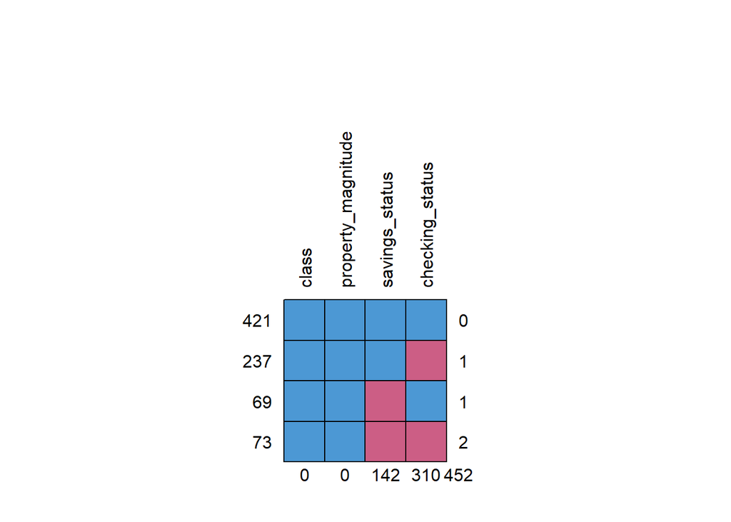

```
##     class property_magnitude savings_status checking_status
## 421     1                  1              1               1   0
## 237     1                  1              1               0   1
## 69      1                  1              0               1   1
## 73      1                  1              0               0   2
##         0                  0            142             310 452
```

```r
train[seq] %>%
  md.pattern(plot = TRUE, rotate.names = TRUE)
```

```r
test[seq]
```

| class | checking_status | savings_status | property_magnitude |
| --- | --- | --- | --- |
| good | NA | 1 | no known property |
| good | 2 | 1 | real estate |
| good | 1 | 1 | life insurance |
| good | NA | no known savings | car |
| good | 2 | no known savings | real estate |
| bad | 1 | 1 | car |
| good | 2 | 1 | real estate |
| good | NA | no known savings | real estate |
| good | 2 | 1 | no known property |
| bad | 2 | 1 | real estate |

[output cut: 190 more lines]

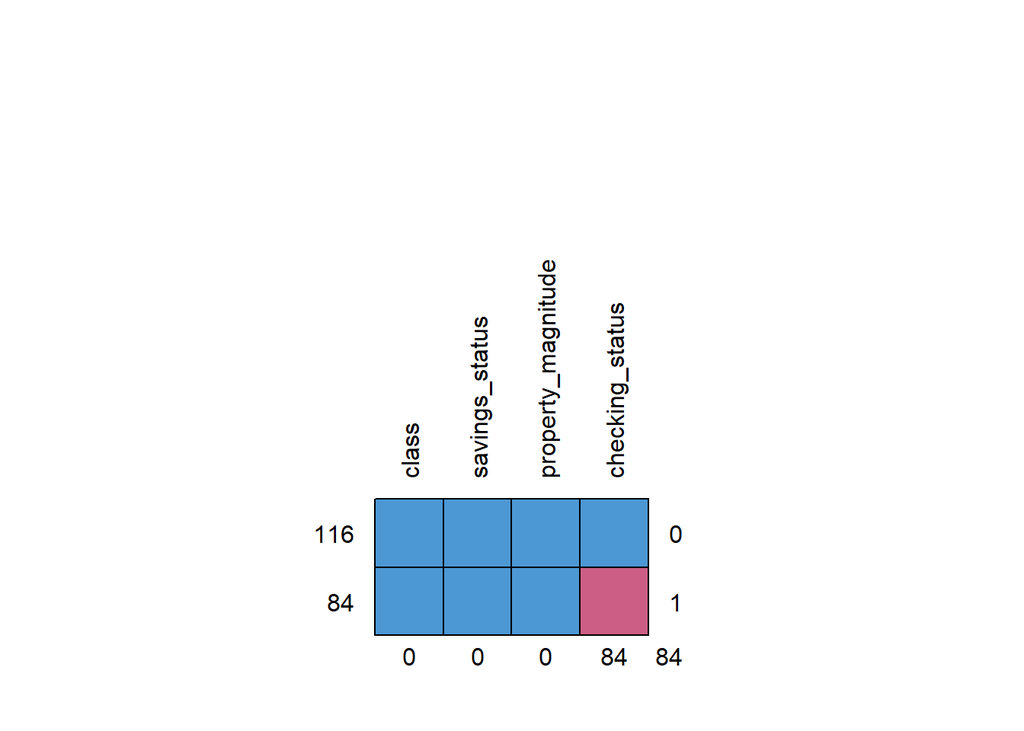

```
##     class savings_status property_magnitude checking_status
## 116     1              1                  1               1  0
## 84      1              1                  1               0  1
##         0              0                  0              84 84
```

```r
test[seq] %>%
  md.pattern(plot = TRUE, rotate.names = TRUE)
```

## Q11

### 결측치 여부에 따라 변수 간의 간략한 분포 plot 그리기 및 해석

```r
library(finalfit)
train
```

| X | id | checking_status | duration | credit_history | purpose | credit_amount | savings_status | employment | installment_commitment | other_parties | residence_since | property_magnitude | age | other_payment_plans | housing | existing_credits | job | num_dependents | own_telephone | foreign_worker | class | sex | marital_status |
| --- | --- | --- | --- | --- | --- | --- | --- | --- | --- | --- | --- | --- | --- | --- | --- | --- | --- | --- | --- | --- | --- | --- | --- |
| 1 | 1 | 1 | 6 | critical/other existing credit | radio/tv | 1169 | NA | 4 | 4 | none | 4 | real estate | 67 | none | own | 2 | skilled | 1 | yes | yes | good | male | single |
| 2 | 2 | 2 | 48 | existing paid | radio/tv | 5951 | 1 | 2 | 2 | none | 2 | real estate | 22 | none | own | 1 | skilled | 1 | none | yes | bad | female | div/dep/mar |
| 3 | 3 | NA | 12 | critical/other existing credit | education | 2096 | 1 | 3 | 2 | none | 3 | real estate | 49 | none | own | 1 | unskilled resident | 2 | none | yes | good | male | single |
| 4 | 4 | 1 | 42 | existing paid | furniture/equipment | 7882 | 1 | 3 | 2 | guarantor | 4 | life insurance | 45 | none | for free | 1 | skilled | 2 | none | yes | good | male | single |
| 5 | 5 | 1 | 24 | delayed previously | new car | 4870 | 1 | 2 | 3 | none | 4 | no known property | 53 | none | for free | 2 | skilled | 2 | none | yes | bad | male | single |
| 6 | 6 | NA | 36 | existing paid | education | 9055 | NA | 2 | 2 | none | 4 | no known property | 35 | none | for free | 1 | unskilled resident | 2 | yes | yes | good | male | single |
| 7 | 7 | NA | 24 | existing paid | furniture/equipment | 2835 | 3 | 4 | 3 | none | 4 | life insurance | 53 | none | own | 1 | skilled | 1 | none | yes | good | male | single |
| 8 | 8 | 2 | 36 | existing paid | used car | 6948 | 1 | 2 | 2 | none | 2 | car | 35 | none | rent | 1 | high qualif/self emp/mgmt | 1 | yes | yes | good | male | single |
| 9 | 9 | NA | 12 | existing paid | radio/tv | 3059 | 4 | 3 | 2 | none | 4 | real estate | 61 | none | own | 1 | unskilled resident | 1 | none | yes | good | male | div/dep/mar |
| 10 | 10 | 2 | 30 | critical/other existing credit | new car | 5234 | 1 | unemployed | 4 | none | 2 | car | 28 | none | own | 2 | high qualif/self emp/mgmt | 1 | none | yes | bad | male | div/dep/mar |

[output cut: 790 more lines]

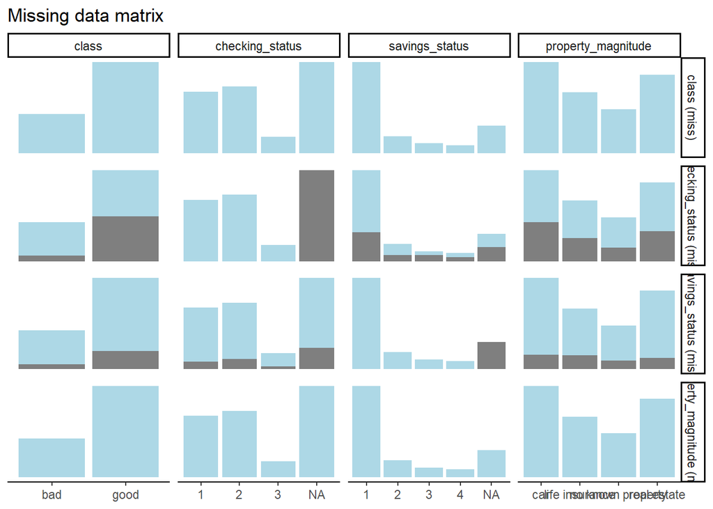

```r
vars <- c("checking_status","savings_status","property_magnitude")
vars2 <- c("class")
train %>% missing_pairs(vars2,vars)
```

## Q12

```r
train
```

| X | id | checking_status | duration | credit_history | purpose | credit_amount | savings_status | employment | installment_commitment | other_parties | residence_since | property_magnitude | age | other_payment_plans | housing | existing_credits | job | num_dependents | own_telephone | foreign_worker | class | sex | marital_status |
| --- | --- | --- | --- | --- | --- | --- | --- | --- | --- | --- | --- | --- | --- | --- | --- | --- | --- | --- | --- | --- | --- | --- | --- |
| 1 | 1 | 1 | 6 | critical/other existing credit | radio/tv | 1169 | NA | 4 | 4 | none | 4 | real estate | 67 | none | own | 2 | skilled | 1 | yes | yes | good | male | single |
| 2 | 2 | 2 | 48 | existing paid | radio/tv | 5951 | 1 | 2 | 2 | none | 2 | real estate | 22 | none | own | 1 | skilled | 1 | none | yes | bad | female | div/dep/mar |
| 3 | 3 | NA | 12 | critical/other existing credit | education | 2096 | 1 | 3 | 2 | none | 3 | real estate | 49 | none | own | 1 | unskilled resident | 2 | none | yes | good | male | single |
| 4 | 4 | 1 | 42 | existing paid | furniture/equipment | 7882 | 1 | 3 | 2 | guarantor | 4 | life insurance | 45 | none | for free | 1 | skilled | 2 | none | yes | good | male | single |
| 5 | 5 | 1 | 24 | delayed previously | new car | 4870 | 1 | 2 | 3 | none | 4 | no known property | 53 | none | for free | 2 | skilled | 2 | none | yes | bad | male | single |
| 6 | 6 | NA | 36 | existing paid | education | 9055 | NA | 2 | 2 | none | 4 | no known property | 35 | none | for free | 1 | unskilled resident | 2 | yes | yes | good | male | single |
| 7 | 7 | NA | 24 | existing paid | furniture/equipment | 2835 | 3 | 4 | 3 | none | 4 | life insurance | 53 | none | own | 1 | skilled | 1 | none | yes | good | male | single |
| 8 | 8 | 2 | 36 | existing paid | used car | 6948 | 1 | 2 | 2 | none | 2 | car | 35 | none | rent | 1 | high qualif/self emp/mgmt | 1 | yes | yes | good | male | single |
| 9 | 9 | NA | 12 | existing paid | radio/tv | 3059 | 4 | 3 | 2 | none | 4 | real estate | 61 | none | own | 1 | unskilled resident | 1 | none | yes | good | male | div/dep/mar |
| 10 | 10 | 2 | 30 | critical/other existing credit | new car | 5234 | 1 | unemployed | 4 | none | 2 | car | 28 | none | own | 2 | high qualif/self emp/mgmt | 1 | none | yes | bad | male | div/dep/mar |

[output cut: 790 more lines]

```r
table(train[c("checking_status","savings_status")])
```

```
##                savings_status
## checking_status   1   2   3   4
##               1 161  10   7   5
##               2 129  42   8  13
##               3  36   4   3   3
```

```r
table(train["property_magnitude"])
```

```
## property_magnitude
##               car    life insurance no known property       real estate
##               266               177               128               229
```

```r
train$checking_status <- ifelse(is.na(train$checking_status),1,train$checking_status)
train$savings_status <- ifelse(is.na(train$savings_status),1,train$savings_status)
train$property_magnitude <- ifelse(is.na(train$property_magnitude),"car",train$property_magnitude)
```

# Chapter 2 : EDA

## Q1

### 변수의 분포 시각화

```r
library(tidyverse)
```

```r
library(ggplot2)
```

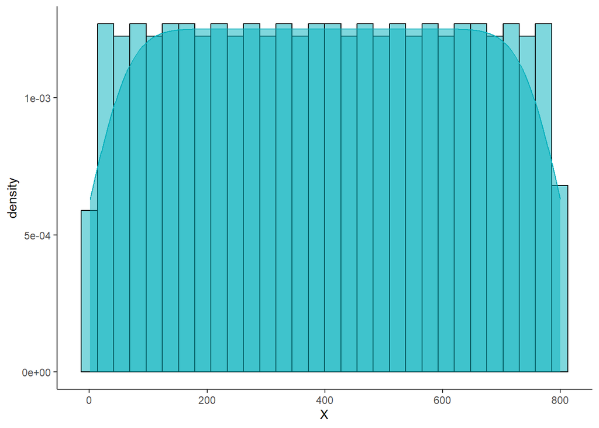

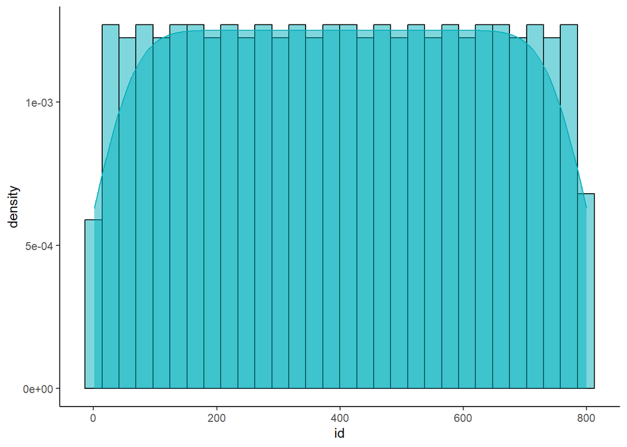

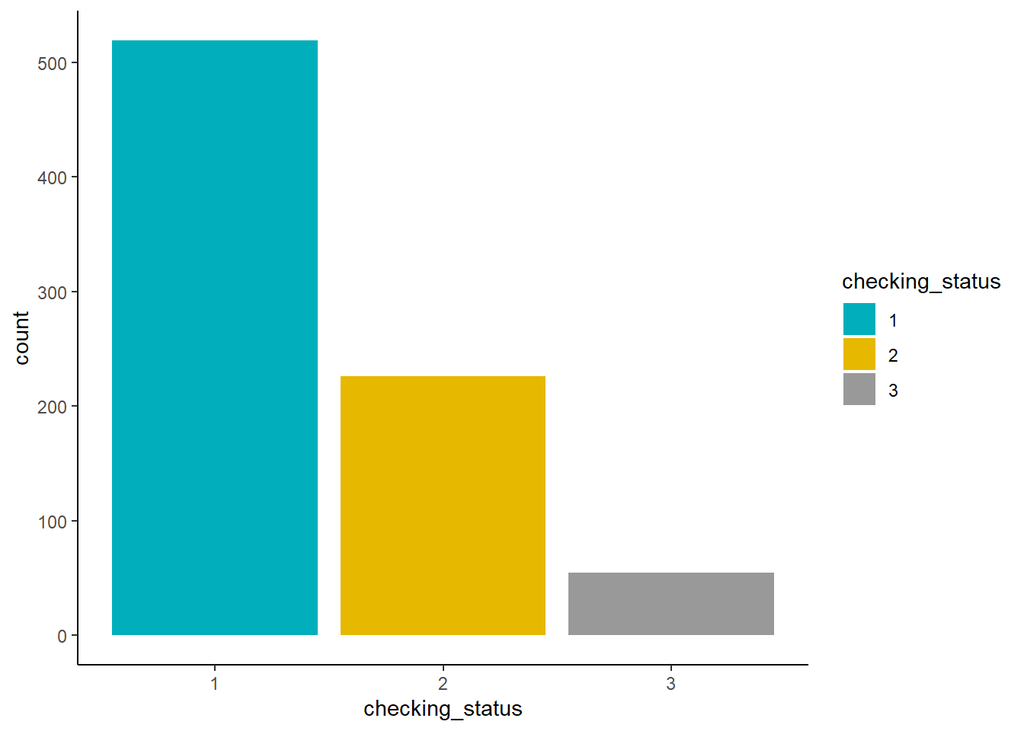

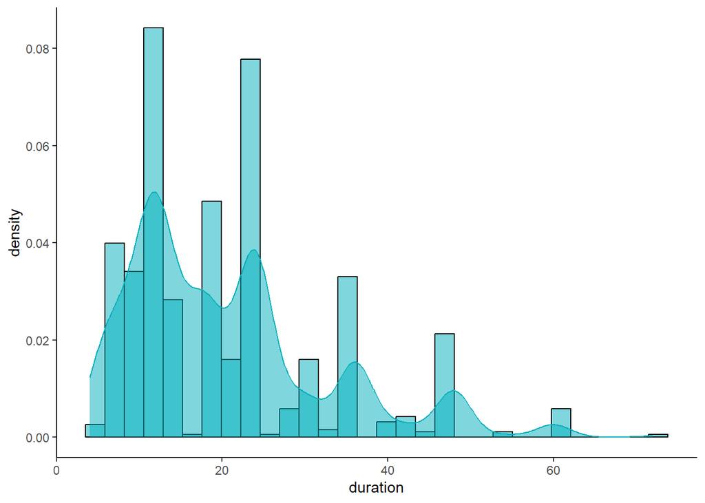

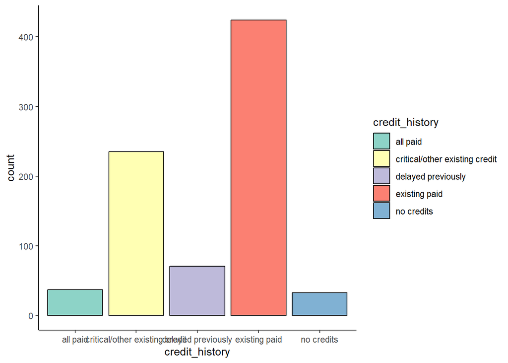

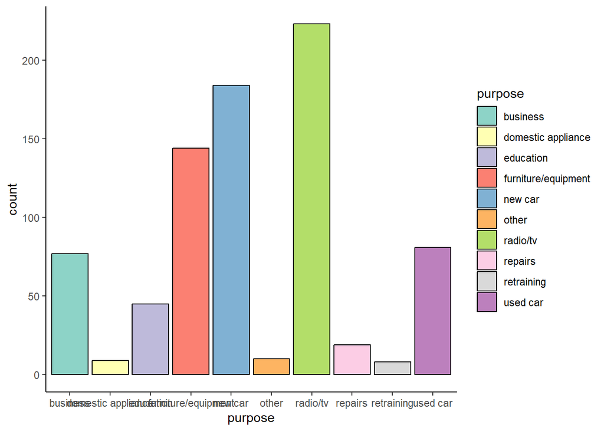

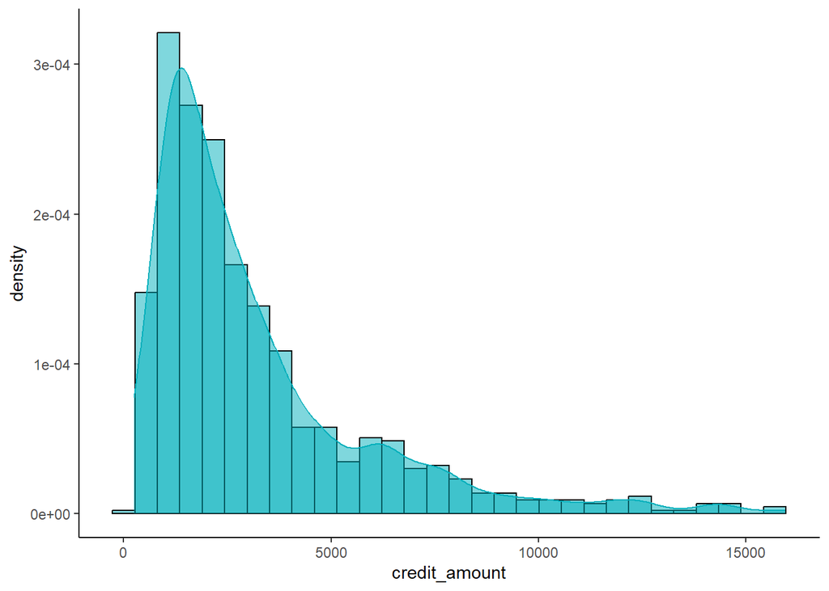

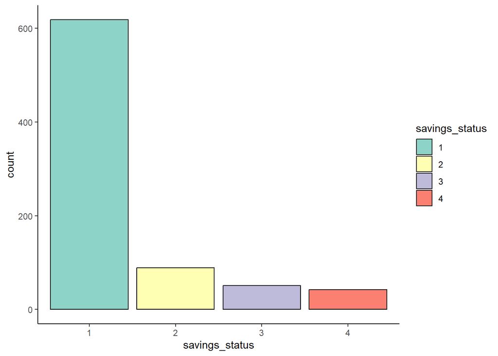

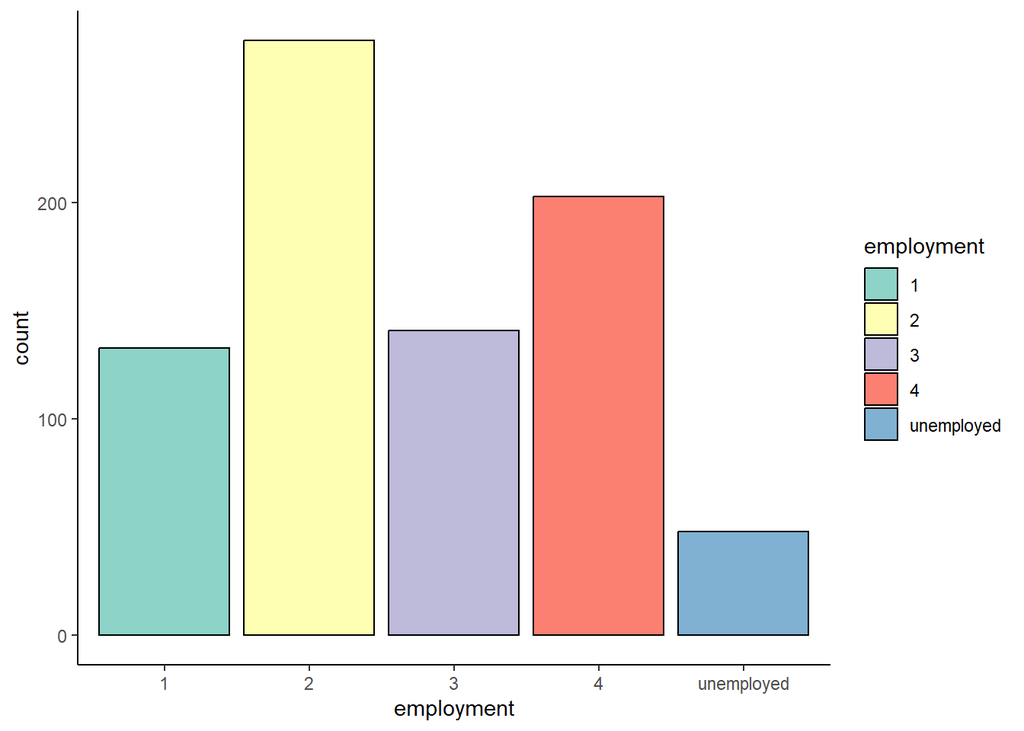

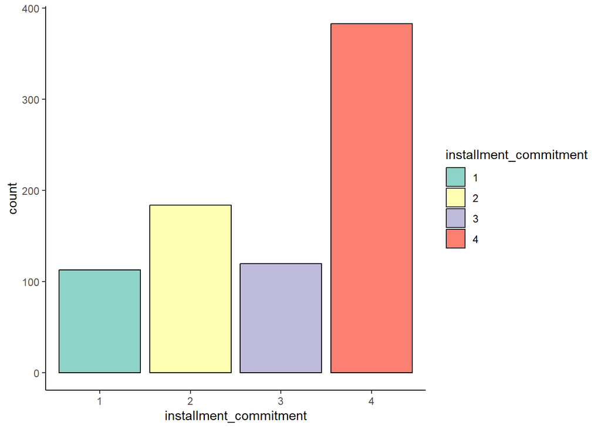

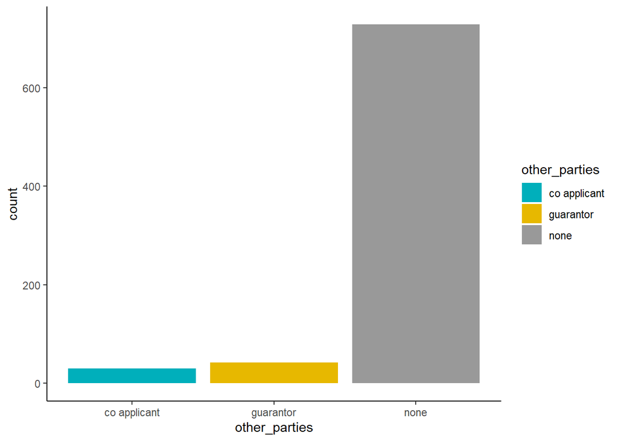

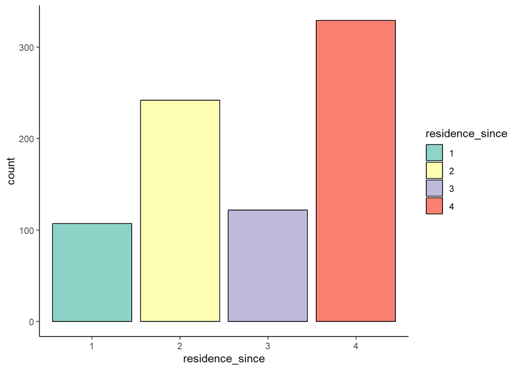

[12 more figures not shown]

```r
train.plot <- list()

for (i in 1:dim(train)[2]){
  cols = colnames(train)[i]
  if (nlevels(as.factor(train[[cols]])) <= 10) {
    tmp = as.factor(train[[cols]])
    if (nlevels(tmp) <= 3) {
      p <- ggplot(data.frame(sapply(train[cols], FUN=as.factor)), aes_string(x=cols, fill=cols)) +
        theme_classic() +
        geom_bar(stat="count") +
        scale_fill_manual(values=c("#00AFBB", "#E7B800", "#999999"))
    }
    else {
      p <- ggplot(data.frame(sapply(train[cols], FUN=as.factor)),
                  aes_string(x=cols, fill=cols)) +
        geom_bar(stat="count", colour="black", size=0.5) +
        scale_fill_brewer(palette="Set3") +
        theme_classic()
    }
  }
  else {
    p <- ggplot(train[cols], aes_string(x=cols, fill=cols)) +
    geom_histogram(aes(y=..density..), fill="#00AFBB", colour="black", alpha=0.5) +
    geom_density(fill="#00AFBB", alpha=0.5, colour="#00AFBB") +
    theme_classic()
  }

  train.plot[[i]] <- p
}
train.plot
```

# Chapter 3 : Modelling

## Q1

### 랜덤포레스트 패키지 불러오기

```r
install.packages("randomForest")
```

```
## Error in contrib.url(repos, "source"): 미러 설정을 하지 않고서는 CRAN을 사용할 수 없습니다
```

```r
library(randomForest)
```

## Q2

### 하이퍼 파라미터 설명

1. formula : 모델을 학습시킬 함수
2. data : 모델을 학습시킬 데이터
3. xtest : 학습된 RandomForest 모델을 평가할 데이터
4. ytest : xtest 파라미터의 평가 데이터셋에 대응하는 종속변인 데이터
5. na.action : data에서 결측치가 발견된 경우 처리 방법을 지정하는 파라미터
6. mtry : 각 노드의 분기에 필요한 변수의 개수
7. ntree : RandomForest 모델을 이루는 트리의 개수
8. importance : RandomForest 모델의 importance 계산 여부를 결정하는 boolean 파라미터터

## Q3

### Ntree를 100으로 설정한 다음에 train 데이터로 학습을 한 후 변수별 중요도를 Importance plot으로 시각화하고 어떤 변수가 대출 승인에 영향을 미치는 지 설명

```r
train.tree <- randomForest(class~.,data = train, ntree = 100,importance = TRUE)
train.tree
```

```
##
## Call:
##  randomForest(formula = class ~ ., data = train, ntree = 100,      importance = TRUE)
##                Type of random forest: classification
##                      Number of trees: 100
## No. of variables tried at each split: 4
##
##         OOB estimate of  error rate: 26%
## Confusion matrix:
##      bad good class.error
## bad   70  169  0.70711297
## good  39  522  0.06951872
```

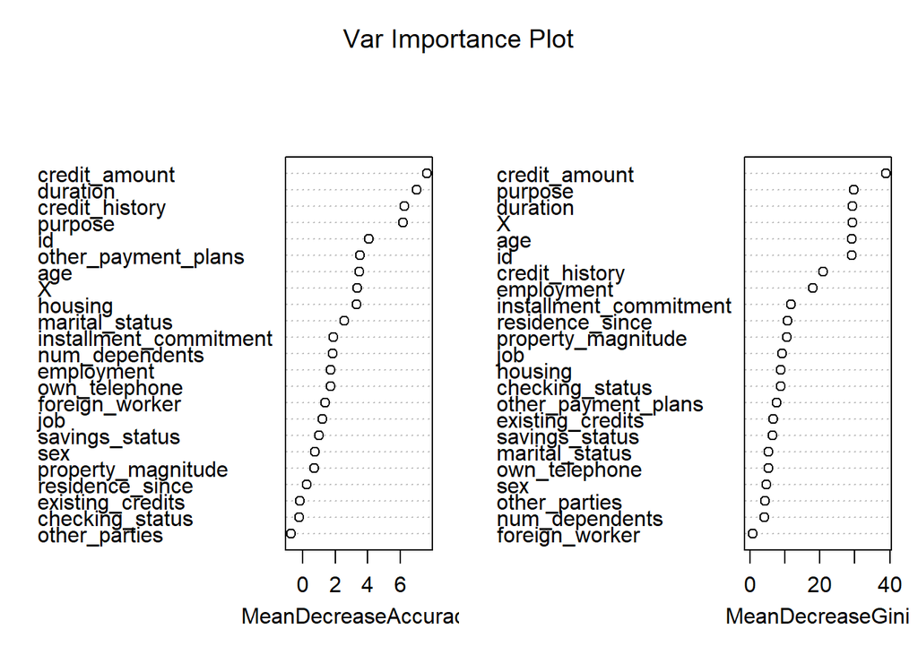

```r
varImpPlot(train.tree, main = "Var Importance Plot")
```

```r
train.tree$importance %>%
  sort(decreasing = TRUE)
```

```
##  [1]  3.893783e+01  2.969488e+01  2.933962e+01  2.925673e+01  2.914919e+01
##  [6]  2.913398e+01  2.102196e+01  1.802663e+01  1.183526e+01  1.075127e+01
## [11]  1.058586e+01  9.234002e+00  8.750079e+00  8.743040e+00  7.615288e+00
## [16]  6.587838e+00  6.479204e+00  5.375442e+00  5.255283e+00  4.758547e+00
## [21]  4.413648e+00  4.037959e+00  8.269900e-01  2.029923e-02  1.933717e-02
## [26]  1.743113e-02  1.637580e-02  1.489730e-02  1.448009e-02  1.331663e-02
## [31]  1.243359e-02  1.232190e-02  1.169185e-02  1.091884e-02  9.995432e-03
## [36]  9.054880e-03  8.493570e-03  7.831719e-03  7.720987e-03  7.196120e-03
## [41]  7.109889e-03  6.379701e-03  6.205801e-03  5.055612e-03  4.354872e-03
## [46]  3.779988e-03  3.655114e-03  3.564757e-03  3.557977e-03  3.557732e-03
## [51]  3.548010e-03  3.275616e-03  3.191356e-03  3.088117e-03  2.714606e-03
## [56]  2.688771e-03  2.612588e-03  2.575003e-03  2.406667e-03  2.073960e-03
## [61]  1.690374e-03  1.434900e-03  1.418345e-03  1.304917e-03  1.240266e-03
## [66]  1.228036e-03  1.045455e-03  1.020781e-03  9.972445e-04  9.481326e-04
## [71]  9.315161e-04  8.459932e-04  8.097473e-04  3.911212e-04  3.566490e-04
## [76]  3.540022e-04  2.956523e-04  2.637750e-04  2.433137e-04  4.574294e-05
## [81] -1.365538e-04 -2.454983e-04 -2.526695e-04 -2.788315e-04 -3.668732e-04
## [86] -4.135337e-04 -4.821694e-04 -9.907599e-04 -1.116509e-03 -2.294576e-03
## [91] -2.618934e-03 -3.219193e-03
```

credit_amount 변수의 중요도가 높으므로 credit_amount가가 대출 승인에 영향을 미친다

## Q4

### 로지스틱 함수로 모든 변수를 다 넣고 돌린 다음에 summary 함수를 이용해서 중요하지 않은 변수를 선택

```r
train_logistic = glm(class~. , data = train, family = "binomial")
summary(train_logistic)
```

```
##
## Call:
## glm(formula = class ~ ., family = "binomial", data = train)
##
## Deviance Residuals:
##     Min       1Q   Median       3Q      Max
## -2.5257  -0.8285   0.4487   0.7453   3.0580
##
## Coefficients: (1 not defined because of singularities)
##                                                Estimate Std. Error z value
## (Intercept)                                   9.873e-01  1.407e+00   0.701
## X                                            -3.872e-04  3.957e-04  -0.978
## id                                                   NA         NA      NA
## checking_status                              -2.141e-01  1.451e-01  -1.476
## duration                                     -3.091e-02  9.934e-03  -3.111
## credit_historycritical/other existing credit  2.052e+00  4.841e-01   4.239
## credit_historydelayed previously              1.420e+00  5.128e-01   2.770
## credit_historyexisting paid                   1.181e+00  4.284e-01   2.756
## credit_historyno credits                      2.009e-01  5.958e-01   0.337
## purposedomestic appliance                    -3.651e-01  9.005e-01  -0.405
## purposeeducation                             -9.427e-01  4.670e-01  -2.019
## purposefurniture/equipment                   -1.937e-01  3.755e-01  -0.516
## purposenew car                               -8.627e-01  3.619e-01  -2.384
## purposeother                                  4.271e-01  8.694e-01   0.491
## purposeradio/tv                               1.923e-01  3.579e-01   0.537
## purposerepairs                               -5.697e-01  6.148e-01  -0.927
## purposeretraining                             1.604e+00  1.185e+00   1.354
## purposeused car                               1.108e+00  4.836e-01   2.291
## credit_amount                                -1.094e-04  4.807e-05  -2.275
## savings_status                                3.578e-01  1.299e-01   2.755
## employment2                                   2.527e-01  2.567e-01   0.984
## employment3                                   9.159e-01  3.225e-01   2.840
## employment4                                   3.348e-01  3.207e-01   1.044
## employmentunemployed                         -3.982e-01  4.670e-01  -0.853
## installment_commitment                       -3.299e-01  9.311e-02  -3.544
## other_partiesguarantor                        1.488e+00  6.329e-01   2.351
## other_partiesnone                             9.039e-01  4.549e-01   1.987
## residence_since                              -1.042e-02  9.299e-02  -0.112
## property_magnitude                            4.473e-02  7.980e-02   0.561
## age                                           1.906e-02  1.013e-02   1.881
```

[output cut: 52 more lines]

```
## num_dependents                               0.034722 *
## own_telephoneyes                             0.051337 .
## foreign_workeryes                            0.074692 .
## sexmale                                      0.197010
## marital_statussingle                         0.000233 ***
## ---
## Signif. codes:  0 '***' 0.001 '**' 0.01 '*' 0.05 '.' 0.1 ' ' 1
##
## (Dispersion parameter for binomial family taken to be 1)
##
##     Null deviance: 975.68  on 799  degrees of freedom
## Residual deviance: 773.36  on 758  degrees of freedom
## AIC: 857.36
##
## Number of Fisher Scoring iterations: 5
```

## Q5

### CORElearn 패키지를 불러오고 릴리프(Relief) 알고리즘을 이용해 변수 별 중요도를 시각화

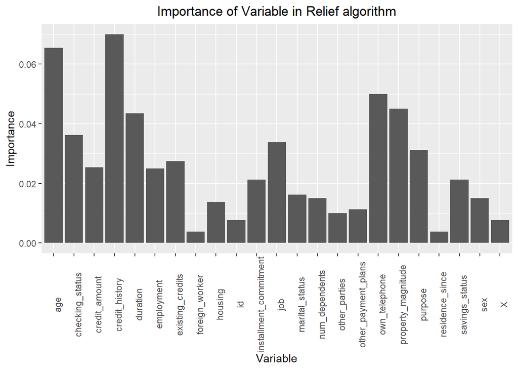

```r
#install.packages("CORElearn")
library(CORElearn)
relief <- attrEval(class~., data = train, estimator = "Relief")
ggplot(dta = relief) +
  geom_bar(aes(x = names(relief),relief), stat = "identity") +
  ggtitle("Importance of Variable in Relief algorithm") +
  xlab("Variable")+
  ylab("Importance") +
  theme(axis.text.x = element_text(angle = 90),
        plot.title = element_text(hjust = 0.5))
```

## Q6

#### Radom forest

```r
rf_imp = importance(train.tree)
rf_imp_dt <- as.data.frame(rf_imp)


rf_selected <- filter(rf_imp_dt,rf_imp_dt[,1]>mean(rf_imp_dt[,1]))
```

```r
relief_dt <- as.data.frame(relief)
relief_selected <- filter(relief_dt, relief_dt[,1]>mean(relief_dt[,1]))
```

```r
#모델 요약 정보 얻기
summary_info <- summary(train_logistic)


final_logsitic <- c()
p_values = coef(summary(train_logistic))[,"Pr(>|z|)"]
selected_p_values = p_values[p_values<0.05]

final_logistic = c()
for(col in colnames(test))
{
  if(sum(grepl(col, names(selected_p_values))))
    final_logistic = c(final_logistic, col)
}
```

*원-핫 인코딩 된 summary의 결과를 기존 변수이름에 맞는 인자들만 추출

```r
final_total <- unique(c(final_logistic,rownames(rf_selected),rownames(relief_selected)))
```

*세 모델에서 필터링한 인자들만 final_total에 모아줌.

```r
final_train <- cbind(train[,final_total],train["class"])
final_train
```

| id | duration | credit_history | purpose | credit_amount | savings_status | employment | installment_commitment | other_parties | num_dependents | marital_status | residence_since | age | other_payment_plans | own_telephone | sex | checking_status | property_magnitude | existing_credits | job | class |
| --- | --- | --- | --- | --- | --- | --- | --- | --- | --- | --- | --- | --- | --- | --- | --- | --- | --- | --- | --- | --- |
| 1 | 6 | critical/other existing credit | radio/tv | 1169 | 1 | 4 | 4 | none | 1 | single | 4 | 67 | none | yes | male | 1 | 4 | 2 | skilled | good |
| 2 | 48 | existing paid | radio/tv | 5951 | 1 | 2 | 2 | none | 1 | div/dep/mar | 2 | 22 | none | none | female | 2 | 4 | 1 | skilled | bad |
| 3 | 12 | critical/other existing credit | education | 2096 | 1 | 3 | 2 | none | 2 | single | 3 | 49 | none | none | male | 1 | 4 | 1 | unskilled resident | good |
| 4 | 42 | existing paid | furniture/equipment | 7882 | 1 | 3 | 2 | guarantor | 2 | single | 4 | 45 | none | none | male | 1 | 2 | 1 | skilled | good |
| 5 | 24 | delayed previously | new car | 4870 | 1 | 2 | 3 | none | 2 | single | 4 | 53 | none | none | male | 1 | 3 | 2 | skilled | bad |
| 6 | 36 | existing paid | education | 9055 | 1 | 2 | 2 | none | 2 | single | 4 | 35 | none | yes | male | 1 | 3 | 1 | unskilled resident | good |
| 7 | 24 | existing paid | furniture/equipment | 2835 | 3 | 4 | 3 | none | 1 | single | 4 | 53 | none | none | male | 1 | 2 | 1 | skilled | good |
| 8 | 36 | existing paid | used car | 6948 | 1 | 2 | 2 | none | 1 | single | 2 | 35 | none | yes | male | 2 | 1 | 1 | high qualif/self emp/mgmt | good |
| 9 | 12 | existing paid | radio/tv | 3059 | 4 | 3 | 2 | none | 1 | div/dep/mar | 4 | 61 | none | none | male | 1 | 4 | 1 | unskilled resident | good |
| 10 | 30 | critical/other existing credit | new car | 5234 | 1 | unemployed | 4 | none | 1 | div/dep/mar | 2 | 28 | none | none | male | 2 | 1 | 2 | high qualif/self emp/mgmt | bad |

[output cut: 790 more lines]

```r
final_model = glm(class~. , data = final_train, family = "binomial")

y_pred_final <- predict(final_model,newdata = final_train, batch_size = 20)

print(y_pred_final)
```

```
##             1             2             3             4             5
##  3.9423020101 -0.1999092285  2.6463345334  1.3418400337  0.1038764244
##             6             7             8             9            10
## -0.4883527857  2.3970838297  1.9722971231  3.5803634571 -1.9308093486
##            11            12            13            14            15
## -0.0425486669 -0.7135090601  2.2956025656  1.6160918814  0.5117834808
##            16            17            18            19            20
##  1.1567734203  2.4197568748 -1.3110445402  0.5867350382  2.3211853786
##            21            22            23            24            25
##  1.8131112916  3.0577543853  1.9715847773  3.9687003146  1.7083954464
##            26            27            28            29            30
##  3.0386212658  0.3052358212  0.9236967583  2.8564551819  0.8344017946
##            31            32            33            34            35
##  1.5659564499  1.0946648433  1.0609410815  3.1772958297 -0.0303238457
##            36            37            38            39            40
##  0.4420251130  1.0085717255  0.1562754885  2.1792623197  1.7525228919
##            41            42            43            44            45
##  1.3794713496  2.1274872462  1.1216161873  2.8861144277  1.0256770601
##            46            47            48            49            50
##  0.1174336281  1.8257618567  4.1949099404  1.8754444693  0.5843916528
##            51            52            53            54            55
##  0.4028894611  2.6023675785  2.1655542534  3.5509477450  0.2915190221
##            56            57            58            59            60
##  0.7254278946  1.7289798371  0.3885850899 -0.6778970656 -0.9693239525
##            61            62            63            64            65
##  1.4270868609  3.6404975673  0.3776963174 -1.1546747945  0.5245813188
##            66            67            68            69            70
## -0.6116350525  1.1558326161  0.6460989673 -0.0471239806 -0.0218259538
##            71            72            73            74            75
##  1.1265110530  3.6051584413  2.8562356147  1.1785750692  0.0797480740
##            76            77            78            79            80
##  3.6750215554  0.3479655806  3.1591090419 -0.2738239469 -0.3465362716
##            81            82            83            84            85
##  1.4443907114  3.0207754133  1.1584931217  2.5334796097  2.6099758008
##            86            87            88            89            90
##  2.3821476762  0.6728172388 -0.2366935523  1.0498579188  0.4958893352
##            91            92            93            94            95
##  3.4345951697  4.2015786399  1.3409215897 -0.1635372894  2.5953349003
##            96            97            98            99           100
## -1.6025331181  2.0095555214  1.3916980185  1.7976016332  1.6924798892
```

[output cut: 265 more lines]

```
##  2.1765125911  0.5275736372  1.3000145797 -0.0147495495  0.9171119851
##           766           767           768           769           770
##  0.9100516170 -0.4041753663  2.2379782475  2.2936198971  3.9204209465
##           771           772           773           774           775
##  1.6891805064 -0.9827475186  4.0266624996  2.1296086463  1.9417707139
##           776           777           778           779           780
## -0.7969901170  1.1946662539  1.7383287262  3.1426187450  0.3200914704
##           781           782           783           784           785
##  2.5940821304  3.1156053470  2.9887037824 -0.7423609569  1.1776789499
##           786           787           788           789           790
##  2.4948249835  2.2699433869  1.6939240574 -1.0745902336 -0.1540248615
##           791           792           793           794           795
##  0.3512318037  1.4713467596  1.8963024237 -0.2440711018  1.8125892211
##           796           797           798           799           800
##  0.8754945970  2.7487192433  1.1292703181 -0.0949746275  0.9380286811
```

### Q7

```r
y_test = ifelse(train['class']=="good",1,0)

pred = ifelse(y_pred_final >0.5, 1,0)

F1_Score(as.vector(y_test),as.vector(pred),positive = 1)
```

```
## Error in F1_Score(as.vector(y_test), as.vector(pred), positive = 1): 함수 "F1_Score"를 찾을 수 없습니다
```